# Introduction to the package MFA

Michelle Huang and Kara Yang

2016-11-30

We will use the dataset ‘mtcars’ to demostrate the usages of ‘MFA’ package.

## GSVD:

The GSVD generalizes the SVD of a matrix by incorporating two additional positive definite matrices that represent“constraints”to be incorporated in the decomposition.

GSVD is a function that performs Generalized Singular Value Decomposition.

Output includes:

d - Vector line with the singular values of the result(from largest to smallest)

u - Line eigenvectors

v - Column relative eigenvectors

##### Here is how to get Generalized Singular Value Decomposition of a matrix:

```r
GSVD(Data=mtcars)
```

```
## $d
##  [1] 1726.658651  227.637939   88.246069   11.918884    5.640189
##  [6]    4.209141    2.581988    1.622713    1.402483    1.173273
## [11]    1.105263
##
## $u
##              [,1]        [,2]         [,3]         [,4]         [,5]
##  [1,] -0.11320047 -0.05633691  0.128807583 -0.001379668  0.384411844
##  [2,] -0.11321869 -0.05648606  0.132272522  0.040220988  0.374512315
##  [3,] -0.08251791 -0.11393550  0.181696859  0.112149326 -0.209532965
##  [4,] -0.16164916  0.16813062  0.159014339 -0.013171265 -0.144836859
##  [5,] -0.23134240  0.16403055  0.015693202 -0.214515779 -0.078640448
##  [6,] -0.14378666  0.11245618  0.138257036  0.252504294 -0.191139336
##  [7,] -0.25215448 -0.09201883 -0.157021202 -0.067215151 -0.162431434
##  [8,] -0.09243308  0.08803081  0.264372207  0.088646257  0.139601599
```

[output cut: 128 more lines]

## MFA:

The general idea behind MFA is to normalize each of the individual data sets so that their first principal component has the same length and then to combine these data tables into a common representation of the observations sometimes called the compromise, or the consensus. This compromise is obtained from a (non-normalized) PCA of the grand table obtained from the concatenation of the normalized data tables. This PCA decomposes the variance of the compromise into a set of new orthogonal variables ordered by the amount of variance that each component explains. The coordinates of the observations on the components are called factor scores and these can be used to plot maps of the observationsin which the observations are represented as points such that the distances in the map best reflect the similarities between the observations. The positions of the observations ‘as seen by’ each data set are called partial factor scores and can be also represented as points in the compromise map. The average of the factor scores of all the tables gives back the factor score of the compromise.

Output includes:

Dimension - Number of the components

Sets - Number of the sets

M - masses for the rows

A - squared singular value derived weights for the k tables

PLin - Vector with weights for lines

PCol - Vector with weights for columns

MatrixA - Matrix with eigenvalues (Variances)

MatrixU - Matrix U of the SVD of Matrix Z

MatrixV - Matriz V of the SVD of Natrix Z

MatrixF - Compromise Factor Score Matrix

MatrixEFG - Partial Factor Score Matrix

MatrixCCP - Matrix with Correlation of Principal Components with Groups

MatrixEscVar - Matrix of Partial Inertia

##### Here is how to create a basic ‘mfa’ object:

```r
mfa(data=mtcars,sets=list(1:3,4:6,7:8,9:11), ncomps = 2, center = TRUE, scale = TRUE)
```

```
## object: "mfa"
## Dimension: "2"
## Number of the sets: "4"
## Mass of each row:"0.03125"
## Weight of each set:
##           weight
## table1 0.3656662
## table2 0.4504676
## table3 0.5732185
## table4 0.5378861
```

##### Here is how to plot a ‘mfa’ object:

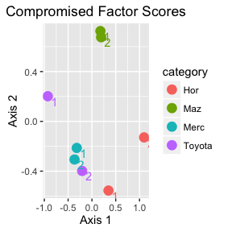

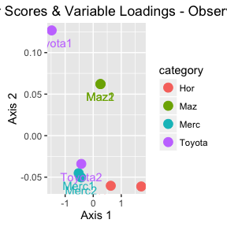

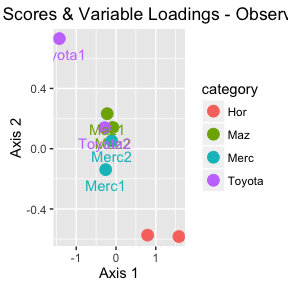

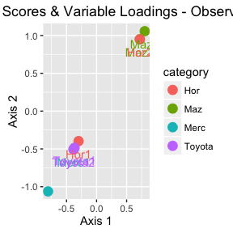

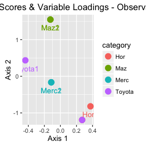

```r
plot(MFA=mfa(mtcars[c(1:2,4:5,8:9,20:21),],sets=list(1:3,4:6,7:8,9:11)),labels=c("Maz1","Maz2","Hor1","Hor2","Merc1","Merc2","Toyota1","Toyota2"),dim1=1,dim2=2)
```

##### Here is how to plot for compromised factor scores:

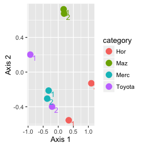

```r
plot_factorscore(mtcars[c(1:2,4:5,8:9,20:21),],sets=list(1:3,4:6,7:8,9:11),dim1=1,dim2=2,
                 labels=c("Maz1","Maz2","Hor1","Hor2","Merc1","Merc2","Toyota1","Toyota2"))
```

##### Here is how to plot for partial factor scores and variable loadings:

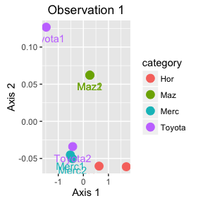

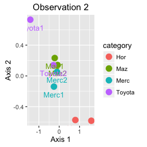

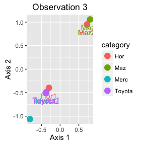

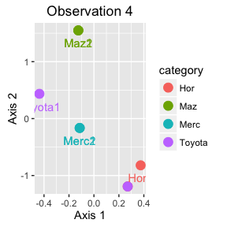

```r
plot_partialfs(mtcars[c(1:2,4:5,8:9,20:21),],sets=list(1:3,4:6,7:8,9:11),dim1=1,dim2=2,
               labels=c("Maz1","Maz2","Hor1","Hor2","Merc1","Merc2","Toyota1","Toyota2"))
```

##### Here is how to print summary of eigen values:

```r
mt.mfa<-mfa(data=mtcars,sets=list(1:3,4:6,7:8,9:11), ncomps = NULL, center = TRUE, scale = TRUE)
summary(mt.mfa,ncomps=2)
```

```
##        Singular value Eigenvalue % cumulative eigenvalue % Inertia
## Axis 1      0.3033280 0.09200785              0.09200785  56.52785
## Axis 2      0.2100001 0.04410004              0.13610789  27.09421
##        % cumulative Inertia
## Axis 1             56.52785
## Axis 2             83.62206
```

## Bootstrap:

We use bootstrap to estimate the stability of the compromise factor scores. The main idea is to use center of gravity which indicate that th compromise factor scores are the average of the partial factor scores. Therefore, we can obtain bootstrap confidence intervals(CIs)by repeatedly sampling with replacement from the set of tables and compute new compromise factor scores.

##### Here is how to perform bootstrap for partial factor scores:

```r
bootstrap(dataset=mtcars,sets=list(1:3,4:6,7:8,9:11), ncomps=NULL, center=TRUE, scale=TRUE, k=10,B=100)
```

```
## $Mean
## $Mean[[1]]
##  [1] -0.05586461 -0.05519081 -0.33700797 -0.05739510  0.23044071
##  [6] -0.03366030  0.36114847 -0.24289025 -0.28697262 -0.06629781
## [11] -0.06987231  0.26964214  0.24627440  0.25238024  0.44005254
## [16]  0.44872265  0.41769258 -0.44983143 -0.49280917 -0.49387354
## [21] -0.22556158  0.25395992  0.21388859  0.34859355  0.26017196
## [26] -0.42306570 -0.28544183 -0.38731180  0.15282237  0.03030053
## [31]  0.33007459 -0.29311843
##
## $Mean[[2]]
##  [1]  0.236975073  0.211636894 -0.009176711 -0.310517550 -0.103888651
##  [6] -0.365185105  0.032869553 -0.186493692 -0.266129281 -0.024983881
## [11] -0.047678366 -0.096083758 -0.096611630 -0.113240433 -0.116383681
## [16] -0.105170128 -0.066347066 -0.028875944  0.096269987 -0.028622268
```

[output cut: 295 more lines]

##### Here is how to plot for ‘bootstrap’ object:

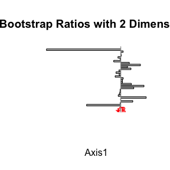

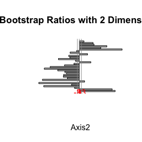

```r
plot(bootstrap(dataset=mtcars,sets=list(1:3,4:6,7:8,9:11), ncomps=2, center=TRUE, scale=TRUE, k=10,B=100))
```

## Lg coefficient:

The Lg coefficient reflects the MFA normalization and takes positive values.An eigen-decomposition of the K by K between-table of Rv or Lg coefficients can provide factor scores for the tables.

##### Here is how to get Lg coefficient between two tables:

```r
mfa1=mfa(data=mtcars,sets=list(1:3,4:6,7:8,9:11), ncomps = NULL, center = TRUE, scale = TRUE)
table_1<-mfa1$MatrixZ[,1:3]
table_2<-mfa1$MatrixZ[,4:6]
Lg(MFA=mfa1,table1=table_1,table2=table_2,order1=1,order2=2)
```

```
## [1] 0.9113934
```

##### Here is how to get Lg coefficient across all the tables:

```r
Lg_table(mtcars,sets=list(1:3,4:6,7:8,9:11),center=TRUE,scale=TRUE)
```

```
##           [,1]      [,2]      [,3]      [,4]
## [1,] 1.0050277 0.9113934 0.4854514 0.4920668
## [2,] 0.9113934 1.0726025 0.4041267 0.6409916
## [3,] 0.4854514 0.4041267 1.0214438 0.2848844
## [4,] 0.4920668 0.6409916 0.2848844 1.2781962
```

## Rv coefficient:

The Rv coefficient varies between 0 and 1 and relects the amount of variance shared by two matrices.

##### Here is how to get RV coefficient between two tables:

```r
mfa1=mfa(data=mtcars,sets=list(1:3,4:6,7:8,9:11), ncomps = NULL, center = TRUE, scale = TRUE)
table_1<-mfa1$MatrixZ[,1:3]
table_2<-mfa1$MatrixZ[,4:6]
RV(table1=table_1,table2=table_2,center=TRUE,scale=TRUE)
```

```
## [1] 0.8778039
```

##### Here is how to get RV coefficient between multiple tables:

```r
RV_table(mtcars,sets=list(1:3,4:6,7:8,9:11),center=TRUE,scale=TRUE)
```

```
##           [,1]      [,2]      [,3]      [,4]
## [1,] 1.0000000 0.8778039 0.4791258 0.4341465
## [2,] 0.8778039 1.0000000 0.3860921 0.5474370
## [3,] 0.4791258 0.3860921 1.0000000 0.2493232
## [4,] 0.4341465 0.5474370 0.2493232 1.0000000
```

## Contributions:

###### contr 1: Contribution of an observation to a dimension

Contributions take values between 0 and 1, and for a given component, the sum of the contributions of all observations is equal to 1. The larger a contribution, the more the observation contributes to the component.

##### Here is how to get contributions:

```r
contr1 <- contributions(X=mtcars,sets=list(1:3,4:6,7:8,9:11),type=1)
contr1
```

```
##               [,1]         [,2]         [,3]         [,4]         [,5]
##  [1,] 0.0010971308 3.780647e-02 0.0194760876 2.493465e-02 0.0619927286
##  [2,] 0.0010750044 3.012248e-02 0.0085346990 4.200181e-02 0.0970036017
##  [3,] 0.0388434421 5.823201e-05 0.0048907200 1.956751e-02 0.0016619502
##  [4,] 0.0011008779 6.472486e-02 0.0003912097 6.071023e-02 0.0115735591
##  [5,] 0.0184698579 7.171521e-03 0.0590415650 2.057128e-04 0.0065783068
##  [6,] 0.0003680887 8.962209e-02 0.0017359972 1.184060e-01 0.0094165649
##  [7,] 0.0447732668 7.377591e-04 0.0054620771 5.220923e-03 0.0585701446
##  [8,] 0.0207154600 2.340092e-02 0.0425288239 2.033751e-05 0.0116627488
##  [9,] 0.0284555672 4.792437e-02 0.1557473143 3.612199e-02 0.0401831158
## [10,] 0.0015203729 4.259208e-04 0.1135511479 1.385424e-04 0.0311614764
## [11,] 0.0016454072 1.554544e-03 0.1422181611 1.511258e-03 0.0167223100
## [12,] 0.0247697927 6.120229e-03 0.0067669950 9.547814e-05 0.0092368365
## [13,] 0.0206772547 6.188921e-03 0.0100378978 2.269923e-04 0.0084028120
## [14,] 0.0218983411 8.552141e-03 0.0039836298 9.030209e-05 0.0155633503
```

[output cut: 84 more lines]

```r
contr2 <- contributions(X=mtcars,sets=list(1:3,4:6,7:8,9:11),type=2)
contr2
```

```
##             [,1]         [,2]        [,3]        [,4]         [,5]
##  [1,] 0.10661847 0.0008410455 0.035181658 0.001177411 0.0008356186
##  [2,] 0.11527260 0.0004413449 0.015476412 0.002045212 0.0163967010
##  [3,] 0.10962473 0.0031296162 0.001704538 0.009916984 0.0464073850
##  [4,] 0.09099868 0.0361272475 0.019792620 0.047116011 0.1630705160
##  [5,] 0.06856976 0.0557584703 0.012932003 0.588641352 0.2234913967
##  [6,] 0.09560674 0.0178189619 0.081727102 0.072034901 0.0311159844
##  [7,] 0.03658688 0.1426308512 0.101726360 0.029361231 0.1019323457
##  [8,] 0.08110751 0.0331241385 0.123967619 0.143554958 0.2104275929
##  [9,] 0.04230862 0.1347656552 0.030320843 0.001027353 0.0396296869
## [10,] 0.03270770 0.1530105674 0.062648673 0.049185758 0.0357995600
## [11,] 0.04030425 0.1098702142 0.214884189 0.001297167 0.0361108792
##              [,6]         [,7]         [,8]         [,9]        [,10]
##  [1,] 0.001537151 1.125509e-02 0.9348981741 3.164641e-01 0.0271572107
##  [2,] 0.004782579 3.705323e-04 0.0672879694 5.563785e-03 1.1360564022
```

[output cut: 21 more lines]

```r
contr3 <- contributions(X=mtcars,sets=list(1:3,4:6,7:8,9:11),type=3)
contr3
```

```
##           [,1]        [,2]       [,3]       [,4]      [,5]       [,6]
## [1,] 0.3315158 0.004412007 0.05236261 0.01313961 0.0636397 0.27350294
## [2,] 0.2551752 0.109704680 0.11445173 0.70779226 0.4176779 0.23151739
## [3,] 0.1176944 0.175754990 0.22569398 0.17291619 0.3123599 0.04866267
## [4,] 0.1153206 0.397646437 0.30785371 0.05151028 0.1115401 0.40579491
##             [,7]       [,8]       [,9]      [,10]      [,11]
## [1,] 0.094353349 1.01047422 0.40535278 1.16331687 0.81810529
## [2,] 0.004802493 0.21887124 0.52275951 0.11015742 0.41396914
## [3,] 0.050853886 0.12123213 0.23333232 0.06204099 0.01866751
## [4,] 0.943327878 0.06625066 0.03797383 0.05078210 0.07725118
```